# A Data-Dive Into Seattle Airbnb Rentals: End-to-End Data Analysis

- Introduction
- Wrangling
- Exploratory Data Analysis
- Regression Analysis
- Conclusion & Areas of Improvement

## Introduction

### Problem Statement

The main purpose of this project is to explore the dynamics of Seattle Airbnb listings, with a focus on rental prices. On the road to doing this, we will undergo data wrangling, exploratory data analysis and multiple regression analysis. At the end of these project, we will draw conclusions, select the most useful features based on our analyses and propose future areas of improvement. We will answer the following questions about our data:

- What is the distribution of listing prices in Seattle? Are they mostly cheap or expensive?
- What are the average prices of listings by neighbourhood? What are the most expensive and least expensive neighbourhoods in Seattle?
- What are the most popular Airbnb room and property types in Seattle?
- What listing features would be most helpful if we wanted to predict rental prices?

### Target Variable

The target variable for this project is **Rental Price**.

To begin the project, we start by importing the relevant Python modules that will be used.

```python
import pandas as pd
import numpy as np
import matplotlib.pyplot as plt
%matplotlib inline
from patsy import dmatrices
import seaborn as sns
import statsmodels.api as sm
from statsmodels.stats.outliers_influence import variance_inflation_factor
```

## Wrangling

In this section, we will load the data to be investigated, check for cleanliness and clean the dataset, ensuring it is ready for analysis.

### Load data

We begin by loading the dataset to be investigated. This dataset can be downloaded [here](https://www.kaggle.com/airbnb/seattle). It consists of three csv files from which we have narrowed down to ten (10) potential input features based on the questions posed in the introduction section. We will also take a quick glance at the first 5 columns of each file to get a feel for what the data looks like. The code block to do these is found in the cell below.

```python
# Load Data
calendar = pd.read_csv('data/calendar.csv')
listings = pd.read_csv('data/listings.csv')
reviews = pd.read_csv('data/reviews.csv')
```

```python
# First 5 rows for calendar.csv
calendar.head()
```

|  | listing_id | date | available | price |
| --- | --- | --- | --- | --- |
| 0 | 241032 | 2016-01-04 | t | $85.00 |
| 1 | 241032 | 2016-01-05 | t | $85.00 |
| 2 | 241032 | 2016-01-06 | f | NaN |
| 3 | 241032 | 2016-01-07 | f | NaN |
| 4 | 241032 | 2016-01-08 | f | NaN |

```python
# First 5 rows for listings.csv
listings.head()
```

|  | id | listing_url | scrape_id | last_scraped | name | summary | space | description | experiences_offered | neighborhood_overview | ... | review_scores_value | requires_license | license | jurisdiction_names | instant_bookable | cancellation_policy | require_guest_profile_picture | require_guest_phone_verification | calculated_host_listings_count | reviews_per_month |
| --- | --- | --- | --- | --- | --- | --- | --- | --- | --- | --- | --- | --- | --- | --- | --- | --- | --- | --- | --- | --- | --- |
| 0 | 241032 | https://www.airbnb.com/rooms/241032 | 20160104002432 | 2016-01-04 | Stylish Queen Anne Apartment | NaN | Make your self at home in this charming one-be... | Make your self at home in this charming one-be... | none | NaN | ... | 10.0 | f | NaN | WASHINGTON | f | moderate | f | f | 2 | 4.07 |
| 1 | 953595 | https://www.airbnb.com/rooms/953595 | 20160104002432 | 2016-01-04 | Bright & Airy Queen Anne Apartment | Chemically sensitive? We've removed the irrita... | Beautiful, hypoallergenic apartment in an extr... | Chemically sensitive? We've removed the irrita... | none | Queen Anne is a wonderful, truly functional vi... | ... | 10.0 | f | NaN | WASHINGTON | f | strict | t | t | 6 | 1.48 |
| 2 | 3308979 | https://www.airbnb.com/rooms/3308979 | 20160104002432 | 2016-01-04 | New Modern House-Amazing water view | New modern house built in 2013. Spectacular s... | Our house is modern, light and fresh with a wa... | New modern house built in 2013. Spectacular s... | none | Upper Queen Anne is a charming neighborhood fu... | ... | 10.0 | f | NaN | WASHINGTON | f | strict | f | f | 2 | 1.15 |
| 3 | 7421966 | https://www.airbnb.com/rooms/7421966 | 20160104002432 | 2016-01-04 | Queen Anne Chateau | A charming apartment that sits atop Queen Anne... | NaN | A charming apartment that sits atop Queen Anne... | none | NaN | ... | NaN | f | NaN | WASHINGTON | f | flexible | f | f | 1 | NaN |
| 4 | 278830 | https://www.airbnb.com/rooms/278830 | 20160104002432 | 2016-01-04 | Charming craftsman 3 bdm house | Cozy family craftman house in beautiful neighb... | Cozy family craftman house in beautiful neighb... | Cozy family craftman house in beautiful neighb... | none | We are in the beautiful neighborhood of Queen ... | ... | 9.0 | f | NaN | WASHINGTON | f | strict | f | f | 1 | 0.89 |

5 rows × 92 columns

```python
# First 5 rows for reviews.csv
reviews.head()
```

|  | listing_id | id | date | reviewer_id | reviewer_name | comments |
| --- | --- | --- | --- | --- | --- | --- |
| 0 | 7202016 | 38917982 | 2015-07-19 | 28943674 | Bianca | Cute and cozy place. Perfect location to every... |
| 1 | 7202016 | 39087409 | 2015-07-20 | 32440555 | Frank | Kelly has a great room in a very central locat... |
| 2 | 7202016 | 39820030 | 2015-07-26 | 37722850 | Ian | Very spacious apartment, and in a great neighb... |
| 3 | 7202016 | 40813543 | 2015-08-02 | 33671805 | George | Close to Seattle Center and all it has to offe... |
| 4 | 7202016 | 41986501 | 2015-08-10 | 34959538 | Ming | Kelly was a great host and very accommodating ... |

#### Descriptions of Attributes we will be working with

- listing_id: Unique identification number for each Airbnb listing
- neighbourhood_group_cleansed: Condensed neighbourhood grouping with most important and "other"
- property_type: Type of property for each listing
- room_type: Type of room being rented out for each listing
- accommodates: Number of guests each listing can accommodate
- bathrooms: Number of bathrooms for each listing
- bedrooms: Number of bedrooms for each listing
- beds: Number of bed in each listing
- square_feet: Area measurement in square feet for each listing
- review_scores_value: Average review score for each listing (scale of 1-10)
- price: Rental Price of each listing

This means we will **not** be using the **reviews** table

#### Select relevant columns and create new dataframes for them

```python
# Select columns from calendar and listings tables

calendar = calendar.drop(['date', 'available'], axis = 1)
listings = listings[['id', 'neighbourhood_group_cleansed', 'property_type', 'room_type', 'accommodates', 'bathrooms', 'bedrooms', 'beds', 'square_feet', 'review_scores_value']]
```

```python
# Rename id column in listings_new to match listing_id in calendar_new
#calendar_new.rename(columns = {'listing_id':'id'}, inplace = True)
```

```python
# Check column name
#calendar_new.info()
```

```python
# Join tables
#df = calendar_new.merge(listings_new, on = 'id', how = 'left')
#df.head()
```

### Check for Cleanliness

There are three common factors (amongst others) to look into when determining the cleanliness of a dataset. These are:

- Incorrect Data types in columns
- Duplication in rows - first in column attributes that should be unique, and then in the row's entirety
- Missing values and the columns that have them

First, we identify these major issues, then we check for any possible minor issues, before we finally clean the data itself.

In addition to cleaning the data, we will need to join data sources as well from the calendar csv and the listings csv.

```python
# Check new calendar dataframe
calendar.head()
```

|  | listing_id | price |
| --- | --- | --- |
| 0 | 241032 | $85.00 |
| 1 | 241032 | $85.00 |
| 2 | 241032 | NaN |
| 3 | 241032 | NaN |
| 4 | 241032 | NaN |

```python
# Check shape of calendar dataframe
calendar.shape
```

```
(1393570, 2)
```

```python
# Check calendar dataframe info
calendar.info()
```

```
<class 'pandas.core.frame.DataFrame'>
RangeIndex: 1393570 entries, 0 to 1393569
Data columns (total 2 columns):
 #   Column      Non-Null Count    Dtype
---  ------      --------------    -----
 0   listing_id  1393570 non-null  int64
 1   price       934542 non-null   object
dtypes: int64(1), object(1)
memory usage: 21.3+ MB
```

From `calendar.info()`, we see that the 'price' column has the datatype `object`, when it should ideally be `float` for computation reasons. We will address converting this in the Data Cleaning section.

```python
# Check new listings dataframe
listings.head()
```

|  | id | neighbourhood_group_cleansed | property_type | room_type | accommodates | bathrooms | bedrooms | beds | square_feet | review_scores_value |
| --- | --- | --- | --- | --- | --- | --- | --- | --- | --- | --- |
| 0 | 241032 | Queen Anne | Apartment | Entire home/apt | 4 | 1.0 | 1.0 | 1.0 | NaN | 10.0 |
| 1 | 953595 | Queen Anne | Apartment | Entire home/apt | 4 | 1.0 | 1.0 | 1.0 | NaN | 10.0 |
| 2 | 3308979 | Queen Anne | House | Entire home/apt | 11 | 4.5 | 5.0 | 7.0 | NaN | 10.0 |
| 3 | 7421966 | Queen Anne | Apartment | Entire home/apt | 3 | 1.0 | 0.0 | 2.0 | NaN | NaN |
| 4 | 278830 | Queen Anne | House | Entire home/apt | 6 | 2.0 | 3.0 | 3.0 | NaN | 9.0 |

```python
# Check shape of listings dataframe
listings.shape
```

```
(3818, 10)
```

```python
# Check listings dataframe info
listings.info()
```

```
<class 'pandas.core.frame.DataFrame'>
RangeIndex: 3818 entries, 0 to 3817
Data columns (total 10 columns):
 #   Column                        Non-Null Count  Dtype
---  ------                        --------------  -----
 0   id                            3818 non-null   int64
 1   neighbourhood_group_cleansed  3818 non-null   object
 2   property_type                 3817 non-null   object
 3   room_type                     3818 non-null   object
 4   accommodates                  3818 non-null   int64
 5   bathrooms                     3802 non-null   float64
 6   bedrooms                      3812 non-null   float64
 7   beds                          3817 non-null   float64
 8   square_feet                   97 non-null     float64
 9   review_scores_value           3162 non-null   float64
dtypes: float64(5), int64(2), object(3)
memory usage: 298.4+ KB
```

```python
print(listings.beds.unique())
```

```
[ 1.  7.  2.  3. 15.  5.  4.  6.  9.  8. nan 10.]
```

In cell above, we explore the the unique values in the 'beds' column in 'listings'. From this, we see that the data type for this should be converted to `int`, as clearly, there is no need to represent it as a `float`.

This difference in number of rows, the info tables as well as the first 5 columns seen earlier tells us that there are duplicate values in the 'listing_id' column of the calendar table. This makes sense due to the same listing being booked on different days. We will take care of eliminating this in the data cleaning section.

Since the 'square_feet' column has only 97 non-null values, we will need to delete (drop) it as there simply isn't enough data here to work with. We will do this in the Data Cleaning section

Next, let's access missing value info in each column for each dataframe.

```python
# Missing value info for each column in listings dataframe
listings.isnull().sum()
```

```
id                                 0
neighbourhood_group_cleansed       0
property_type                      1
room_type                          0
accommodates                       0
bathrooms                         16
bedrooms                           6
beds                               1
square_feet                     3721
review_scores_value              656
dtype: int64
```

```python
# Missing value info for each column in calendar dataframe
calendar.isnull().sum()
```

```
listing_id         0
price         459028
dtype: int64
```

We see that the 'price' column in 'calendar' as well as the 'property_type', 'bathrooms', 'bedrooms', 'beds', 'square_feet' and 'review_scores_value' columns in 'listings' are all culprits. In the Data Cleaning section, we will handle these missing values.

```python
np.array(calendar['price'])
```

```
array(['$85.00', '$85.00', nan, ..., nan, nan, nan], dtype=object)
```

```python
# Number of duplicated rows in calendar dataframe
sum(calendar.duplicated())
```

```
1364256
```

```python
# Number of duplicated rows in listings dataframe
sum(listings.duplicated())
```

```
0
```

We see that there are many duplicated rows in the `calendar` dataframe and none in the `listings` dataframe. Again this will be addressed in the Data Cleaning section.

Finally, in order to properly make use of the data we have from `calendar` and `listings` dataframes, we would need to join them together. This will be the last step in the Data Cleaning section.

### Data Cleaning

In this section will address the data cleanliness issues that were documented in the "Check for Cleanliness" section. We will be working in this order:

- Drop the 'square_feet' column in the 'listings' dataframe
- Drop rows containing missing values in both dataframes
- Change the data types of the 'price' column in the calendar dataframe and the 'beds' column in the 'listings' dataframe
- Average out prices for each unique listing id in the calendar table to handle those repetitions
- Finally, join the two dataframes together

#### Drop the 'square_feet' column in the 'listings' dataframe

```python
# Drop square_feet column
listings.drop(columns = ['square_feet'], inplace = True)
```

```python
# Check that square_feet column is dropped
listings.info()
```

```
<class 'pandas.core.frame.DataFrame'>
RangeIndex: 3818 entries, 0 to 3817
Data columns (total 9 columns):
 #   Column                        Non-Null Count  Dtype
---  ------                        --------------  -----
 0   id                            3818 non-null   int64
 1   neighbourhood_group_cleansed  3818 non-null   object
 2   property_type                 3817 non-null   object
 3   room_type                     3818 non-null   object
 4   accommodates                  3818 non-null   int64
 5   bathrooms                     3802 non-null   float64
 6   bedrooms                      3812 non-null   float64
 7   beds                          3817 non-null   float64
 8   review_scores_value           3162 non-null   float64
dtypes: float64(4), int64(2), object(3)
memory usage: 268.6+ KB
```

We have successfully dropped the 'square_feet' column in the 'listings' dataframe

#### Drop rows containing missing values in both dataframes

```python
# Drop rows with missing values in calendar dataframe
calendar.dropna(inplace = True)
```

```python
# Check that there are no more missing values in calendar dataframe
calendar.isnull().sum()
```

```
listing_id    0
price         0
dtype: int64
```

```python
# Drop rows with missing values in listings dataframe
listings.dropna(inplace = True)
```

```python
# Check that there are no more missing values in listings dataframe
listings.isnull().sum()
```

```
id                              0
neighbourhood_group_cleansed    0
property_type                   0
room_type                       0
accommodates                    0
bathrooms                       0
bedrooms                        0
beds                            0
review_scores_value             0
dtype: int64
```

Our dataframes are now missing-value-free!

#### Change dtype of 'price' column in 'calendar' and 'beds' column in 'listings'

```python
# Clean up the 'price' column by removing visible roadblocks to datatype conversion

calendar['price'] = calendar['price'].str.replace('$', '')
calendar['price'] = calendar['price'].str.replace(',', '')
```

In the cell above, we replaced the visible roadblocks to conversion from object to float by removing commas and currency signs. In the cell below, we will have a quick glance at the array of unique values in this column to see if any other changes jump out at us.

```python
calendar['price'].unique()
```

[output not shown]

[output cut: 54 more lines]

[output not shown]

Looks good to me! Now we can convert this column's data type from object to float. We do this in the cell below

```python
# Convert the 'price' column dtype from object to float
calendar['price'] = calendar['price'].astype(float)
```

No error so it looks like everything is fine. Let's check the calendar dataframe info just to make sure!

```python
# Check conversion
calendar.info()
```

```
<class 'pandas.core.frame.DataFrame'>
Int64Index: 934542 entries, 0 to 1393213
Data columns (total 2 columns):
 #   Column      Non-Null Count   Dtype
---  ------      --------------   -----
 0   listing_id  934542 non-null  int64
 1   price       934542 non-null  float64
dtypes: float64(1), int64(1)
memory usage: 21.4 MB
```

We have successfully converted the 'price' column datatype from object to float. Now, we convert the 'beds' column datatype from float to int. We already viewed the unique values in this column in the "Check for Cleanliness" section and did not find any roadblocks to conversion, so we will just go ahead and convert it.

```python
# Convert the 'beds' column dtype from float to int
listings['beds'] = listings['beds'].astype(int)
```

```python
# Check conversion
listings.info()
```

```
<class 'pandas.core.frame.DataFrame'>
Int64Index: 3144 entries, 0 to 3814
Data columns (total 9 columns):
 #   Column                        Non-Null Count  Dtype
---  ------                        --------------  -----
 0   id                            3144 non-null   int64
 1   neighbourhood_group_cleansed  3144 non-null   object
 2   property_type                 3144 non-null   object
 3   room_type                     3144 non-null   object
 4   accommodates                  3144 non-null   int64
 5   bathrooms                     3144 non-null   float64
 6   bedrooms                      3144 non-null   float64
 7   beds                          3144 non-null   int64
 8   review_scores_value           3144 non-null   float64
dtypes: float64(3), int64(3), object(3)
memory usage: 245.6+ KB
```

Next, we will need to reset index numbers for both dataframes, as is standard procedure after dropping rows (and it makes our data look cleaner!). We know we need to do this by looking at the info for the dataframes in the last few cells. For the calendar dataframe, we see "Int64Index: 934542 entries, 0 to 1393213", and for the listings dataframe, we see "Int64Index: 3144 entries, 0 to 3814"

```python
# Reset index for both dataframes
calendar.reset_index(drop = True, inplace = True)
listings.reset_index(drop = True, inplace = True)
```

```python
# Check info to confirm change for calendar
calendar.info()
```

```
<class 'pandas.core.frame.DataFrame'>
RangeIndex: 934542 entries, 0 to 934541
Data columns (total 2 columns):
 #   Column      Non-Null Count   Dtype
---  ------      --------------   -----
 0   listing_id  934542 non-null  int64
 1   price       934542 non-null  float64
dtypes: float64(1), int64(1)
memory usage: 14.3 MB
```

```python
# Check info to confirm change for listings
listings.info()
```

```
<class 'pandas.core.frame.DataFrame'>
RangeIndex: 3144 entries, 0 to 3143
Data columns (total 9 columns):
 #   Column                        Non-Null Count  Dtype
---  ------                        --------------  -----
 0   id                            3144 non-null   int64
 1   neighbourhood_group_cleansed  3144 non-null   object
 2   property_type                 3144 non-null   object
 3   room_type                     3144 non-null   object
 4   accommodates                  3144 non-null   int64
 5   bathrooms                     3144 non-null   float64
 6   bedrooms                      3144 non-null   float64
 7   beds                          3144 non-null   int64
 8   review_scores_value           3144 non-null   float64
dtypes: float64(3), int64(3), object(3)
memory usage: 221.2+ KB
```

Great! Next, we will average out prices for each unique listing id in the calendar table to handle those repetitions.

#### Average out prices for each unique listing id in the calendar table

We will accomplish this using the `.groupby()` function.

```python
# Group average price by listing id
calendar = calendar.groupby('listing_id').mean()
calendar.head()
```

| listing_id | price |
| --- | --- |
| 3335 | 120.000000 |
| 4291 | 82.000000 |
| 5682 | 53.944984 |
| 6606 | 92.849315 |
| 7369 | 85.000000 |

Then, we use `.reset_index()` to take it from a groupby series back to a dataframe

```python
# Reset the index of the calendar dataframe
calendar = calendar.reset_index()
```

```python
calendar.head()
```

|  | listing_id | price |
| --- | --- | --- |
| 0 | 3335 | 120.000000 |
| 1 | 4291 | 82.000000 |
| 2 | 5682 | 53.944984 |
| 3 | 6606 | 92.849315 |
| 4 | 7369 | 85.000000 |

#### Join the calendar and listing dataframes together.

Finally, we join the `calendar` and `listing` dataframes together.

```python
# Rename id column in listings_new to match listing_id in calendar_new
calendar.rename(columns = {'listing_id':'id'}, inplace = True)
```

```python
# Check column name
calendar.info()
```

```
<class 'pandas.core.frame.DataFrame'>
RangeIndex: 3723 entries, 0 to 3722
Data columns (total 2 columns):
 #   Column  Non-Null Count  Dtype
---  ------  --------------  -----
 0   id      3723 non-null   int64
 1   price   3723 non-null   float64
dtypes: float64(1), int64(1)
memory usage: 58.3 KB
```

```python
# Join tables
df = calendar.merge(listings, on = 'id', how = 'left')
```

```python
df.head()
```

|  | id | price | neighbourhood_group_cleansed | property_type | room_type | accommodates | bathrooms | bedrooms | beds | review_scores_value |
| --- | --- | --- | --- | --- | --- | --- | --- | --- | --- | --- |
| 0 | 3335 | 120.000000 | NaN | NaN | NaN | NaN | NaN | NaN | NaN | NaN |
| 1 | 4291 | 82.000000 | Other neighborhoods | House | Private room | 2.0 | 1.0 | 1.0 | 1.0 | 9.0 |
| 2 | 5682 | 53.944984 | Delridge | Apartment | Entire home/apt | 2.0 | 1.0 | 1.0 | 1.0 | 10.0 |
| 3 | 6606 | 92.849315 | Other neighborhoods | Apartment | Entire home/apt | 2.0 | 1.0 | 1.0 | 1.0 | 9.0 |
| 4 | 7369 | 85.000000 | Capitol Hill | Condominium | Entire home/apt | 2.0 | 1.0 | 1.0 | 1.0 | 9.0 |

```python
# Check for missing values
df.isnull().sum()
```

```
id                                0
price                             0
neighbourhood_group_cleansed    649
property_type                   649
room_type                       649
accommodates                    649
bathrooms                       649
bedrooms                        649
beds                            649
review_scores_value             649
dtype: int64
```

```python
# Drop rows with missing values - We do this because each value represents a particular
# listing, so averaging from other listings will not be appropriate
df.dropna(inplace = True)
```

```python
df.info()
```

```
<class 'pandas.core.frame.DataFrame'>
Int64Index: 3074 entries, 1 to 3660
Data columns (total 10 columns):
 #   Column                        Non-Null Count  Dtype
---  ------                        --------------  -----
 0   id                            3074 non-null   int64
 1   price                         3074 non-null   float64
 2   neighbourhood_group_cleansed  3074 non-null   object
 3   property_type                 3074 non-null   object
 4   room_type                     3074 non-null   object
 5   accommodates                  3074 non-null   float64
 6   bathrooms                     3074 non-null   float64
 7   bedrooms                      3074 non-null   float64
 8   beds                          3074 non-null   float64
 9   review_scores_value           3074 non-null   float64
dtypes: float64(6), int64(1), object(3)
memory usage: 264.2+ KB
```

```python
# Reset the index of our joined dataframe
df.reset_index(drop = True, inplace = True)
```

```python
df.head(5)
```

|  | id | price | neighbourhood_group_cleansed | property_type | room_type | accommodates | bathrooms | bedrooms | beds | review_scores_value |
| --- | --- | --- | --- | --- | --- | --- | --- | --- | --- | --- |
| 0 | 4291 | 82.000000 | Other neighborhoods | House | Private room | 2.0 | 1.0 | 1.0 | 1.0 | 9.0 |
| 1 | 5682 | 53.944984 | Delridge | Apartment | Entire home/apt | 2.0 | 1.0 | 1.0 | 1.0 | 10.0 |
| 2 | 6606 | 92.849315 | Other neighborhoods | Apartment | Entire home/apt | 2.0 | 1.0 | 1.0 | 1.0 | 9.0 |
| 3 | 7369 | 85.000000 | Capitol Hill | Condominium | Entire home/apt | 2.0 | 1.0 | 1.0 | 1.0 | 9.0 |
| 4 | 9419 | 85.616438 | Other neighborhoods | House | Private room | 2.0 | 3.0 | 1.0 | 1.0 | 9.0 |

#### Post-join cleaning

- Convert id from int to object
- Convert accommodates, bedrooms and beds from float to int

```python
# Convert id from int to object
df['id'] = df['id'].astype(str)
```

```python
# Convert accommodates, bedrooms and beds from float to int
df['accommodates'] = df['accommodates'].astype(int)
df['bedrooms'] = df['bedrooms'].astype(int)
df['beds'] = df['beds'].astype(int)
```

```python
df.info()
```

```
<class 'pandas.core.frame.DataFrame'>
RangeIndex: 3074 entries, 0 to 3073
Data columns (total 10 columns):
 #   Column                        Non-Null Count  Dtype
---  ------                        --------------  -----
 0   id                            3074 non-null   object
 1   price                         3074 non-null   float64
 2   neighbourhood_group_cleansed  3074 non-null   object
 3   property_type                 3074 non-null   object
 4   room_type                     3074 non-null   object
 5   accommodates                  3074 non-null   int64
 6   bathrooms                     3074 non-null   float64
 7   bedrooms                      3074 non-null   int64
 8   beds                          3074 non-null   int64
 9   review_scores_value           3074 non-null   float64
dtypes: float64(3), int64(3), object(4)
memory usage: 240.3+ KB
```

```python
df.head(10)
```

|  | id | price | neighbourhood_group_cleansed | property_type | room_type | accommodates | bathrooms | bedrooms | beds | review_scores_value |
| --- | --- | --- | --- | --- | --- | --- | --- | --- | --- | --- |
| 0 | 4291 | 82.000000 | Other neighborhoods | House | Private room | 2 | 1.0 | 1 | 1 | 9.0 |
| 1 | 5682 | 53.944984 | Delridge | Apartment | Entire home/apt | 2 | 1.0 | 1 | 1 | 10.0 |
| 2 | 6606 | 92.849315 | Other neighborhoods | Apartment | Entire home/apt | 2 | 1.0 | 1 | 1 | 9.0 |
| 3 | 7369 | 85.000000 | Capitol Hill | Condominium | Entire home/apt | 2 | 1.0 | 1 | 1 | 9.0 |
| 4 | 9419 | 85.616438 | Other neighborhoods | House | Private room | 2 | 3.0 | 1 | 1 | 9.0 |
| 5 | 9460 | 113.736842 | Downtown | Bed & Breakfast | Private room | 2 | 1.0 | 1 | 1 | 10.0 |
| 6 | 9531 | 169.500000 | West Seattle | House | Entire home/apt | 4 | 1.0 | 2 | 5 | 10.0 |
| 7 | 9534 | 125.000000 | West Seattle | House | Entire home/apt | 3 | 1.0 | 2 | 2 | 10.0 |
| 8 | 9596 | 121.404959 | Other neighborhoods | Apartment | Entire home/apt | 6 | 1.0 | 1 | 6 | 9.0 |
| 9 | 11012 | 312.849315 | Other neighborhoods | House | Entire home/apt | 8 | 2.0 | 3 | 3 | 9.0 |

Looks like we are ready to get into our analysis!

## Exploratory Data Analysis

In this section, we will:

- Explore summary statistics for each numerical variables
- Look further into the distribution of prices between room types, property types and neighbourhoods
- Explore correlations between variables with the target variable and with each other

#### Explore Summary Statistics

```python
# Summary statistics with .describe()
df.describe()
```

|  | price | accommodates | bathrooms | bedrooms | beds | review_scores_value |
| --- | --- | --- | --- | --- | --- | --- |
| count | 3074.000000 | 3074.000000 | 3074.000000 | 3074.000000 | 3074.00000 | 3074.000000 |
| mean | 135.495428 | 3.365973 | 1.255693 | 1.291152 | 1.73650 | 9.455107 |
| std | 98.283141 | 1.980648 | 0.592014 | 0.865211 | 1.15177 | 0.749076 |
| min | 25.000000 | 1.000000 | 0.000000 | 0.000000 | 1.00000 | 2.000000 |
| 25% | 76.629313 | 2.000000 | 1.000000 | 1.000000 | 1.00000 | 9.000000 |
| 50% | 108.586849 | 3.000000 | 1.000000 | 1.000000 | 1.00000 | 10.000000 |
| 75% | 160.657795 | 4.000000 | 1.000000 | 2.000000 | 2.00000 | 10.000000 |
| max | 1301.818182 | 16.000000 | 8.000000 | 7.000000 | 15.00000 | 10.000000 |

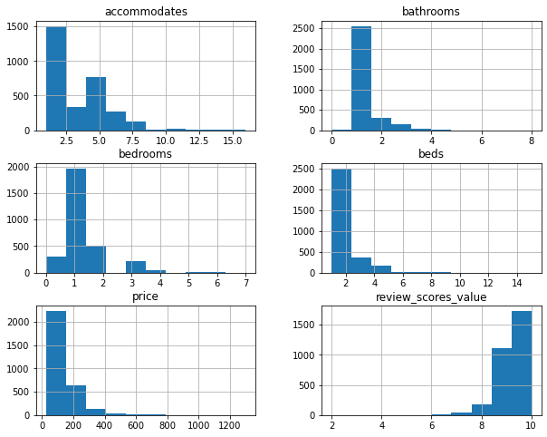

```python
# Distributions of each numerical variable
df.hist(figsize = (10,8));
```

Most features are relatively right-skewed, including price, which could mean most listings are relatively small and inexpensive. Note that this answers our first question posed in the introduction.

We notice that 'review_scores_value' is left-skewed though, which means that most listings had relatively high review scores.

Below is the distribution of Price with the appropriate axes labels and title:

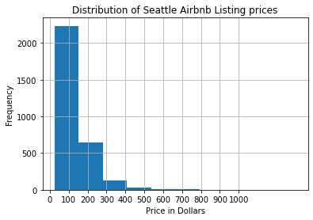

```python
df['price'].hist()
plt.xlabel('Price in Dollars')
ticks_x = [0, 100, 200, 300, 400, 500, 600, 700, 800, 900, 1000]
plt.xticks(ticks_x)
plt.ylabel('Frequency')
plt.title('Distribution of Seattle Airbnb Listing prices');
```

We see that the vast majority of listings are below $150. Let's look further into how prices are distributed among room types and property types.

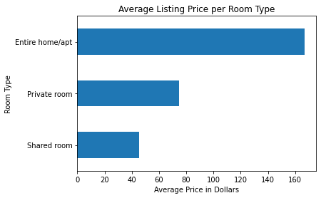

```python
# Average Price per room type

df.groupby('room_type')['price'].mean().sort_values(ascending = True).plot.barh()
plt.ylabel('Room Type')
plt.xlabel('Average Price in Dollars')
plt.title('Average Listing Price per Room Type');
```

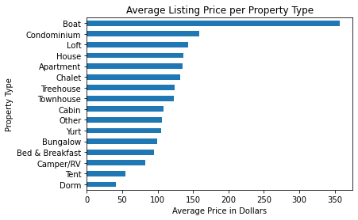

```python
# Average Price per property type

df.groupby('property_type')['price'].mean().sort_values(ascending = True).plot.barh()
plt.ylabel('Property Type')
plt.xlabel('Average Price in Dollars')
plt.title('Average Listing Price per Property Type');
```

We see that on average, Entire Homes/Apts are more expensive that private rooms and shared rooms respectively, which makes sense. We also see that boats are by far the most expensive property types on average, which, again we would expect.

There must not be many Boat properties in Seattle then, since the distribution of all the listing prices is skewed in favor of the lower prices. We will find out about this soon enough!

Let's explore the data further by looking at the most popular room types and property types:

```python
base_color = sns.color_palette()[0]
```

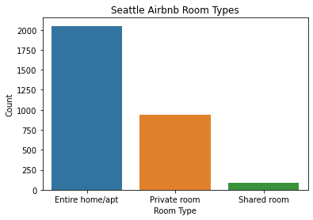

```python
# Room type popularity
sns.countplot(data = df, x = 'room_type', order = df['room_type'].value_counts().index).set_title('Seattle Airbnb Room Types')
plt.xlabel('Room Type')
plt.ylabel('Count');
```

Just like the distribtion of prices, in general Entire Homes/Apts are more popular than Private and Shared Rooms respectively.

Next, let's see where Homes and Apartments fit in the bigger picture. Just how popular are these listings in the Seattle area?

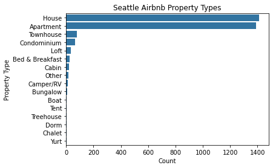

```python
# Property type popularity

sns.countplot(data = df, y = 'property_type', order = df['property_type'].value_counts().index, color = base_color).set_title('Seattle Airbnb Property Types')
plt.ylabel('Property Type')
plt.xlabel('Count');
```

It turns out that Homes and Apartments are by far the most popular listings, while boats are almost non-existent. We see below though, that there are 5 boats in our dataset, less than 1%.

```python
number_of_boats = len(df[df['property_type'] == 'Boat'])
print(number_of_boats)
```

```
5
```

```python
number_of_boats/len(df)
```

```
0.0016265452179570592
```

In fact, we also see that Condomoniums and Lofts (the next most expensive listings), though more popular than Boats, do not come close in popularity to Homes and Apartments.

We see now, that the distribution of prices makes a lot more sense.

Next, we look into average listing prices per neighbourhood to see which neighbourhoods are the most expensive and least expensive.

We use the narrowed down neighbourhood column so that our visualization does not look too cluttered, and because we only really care about the extremes.

```python
# Average neighbourhood prices
neighb_price = df.groupby('neighbourhood_group_cleansed')['price'].mean()
neighb_price
```

```
neighbourhood_group_cleansed
Ballard                126.289481
Beacon Hill             92.366825
Capitol Hill           134.112822
Cascade                152.878415
Central Area           130.106931
Delridge                86.769895
Downtown               179.339898
Interbay                97.247691
Lake City               96.596635
Magnolia               205.161841
Northgate               96.529408
Other neighborhoods    124.732712
Queen Anne             172.074174
Rainier Valley          93.676319
Seward Park            109.725634
University District    104.188618
West Seattle           134.784205
Name: price, dtype: float64
```

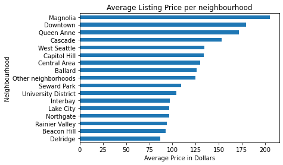

```python
neighb_price.sort_values(ascending = True).plot.barh()
plt.ylabel('Neighbourhood')
plt.xlabel('Average Price in Dollars')
plt.title('Average Listing Price per neighbourhood');
```

#### Explore Correlations

Here, we explore correlations between variables with the target variable and with each other

```python
# Dataframe of correlations between variables
correl = df.corr()
correl
```

|  | price | accommodates | bathrooms | bedrooms | beds | review_scores_value |
| --- | --- | --- | --- | --- | --- | --- |
| price | 1.000000 | 0.695030 | 0.535911 | 0.649688 | 0.629883 | -0.040762 |
| accommodates | 0.695030 | 1.000000 | 0.519341 | 0.767062 | 0.861368 | -0.066896 |
| bathrooms | 0.535911 | 0.519341 | 1.000000 | 0.598875 | 0.520964 | 0.015253 |
| bedrooms | 0.649688 | 0.767062 | 0.598875 | 1.000000 | 0.748724 | -0.003174 |
| beds | 0.629883 | 0.861368 | 0.520964 | 0.748724 | 1.000000 | -0.033706 |
| review_scores_value | -0.040762 | -0.066896 | 0.015253 | -0.003174 | -0.033706 | 1.000000 |

Let's represent these correlations in a heatmap to visualize the relationships better.

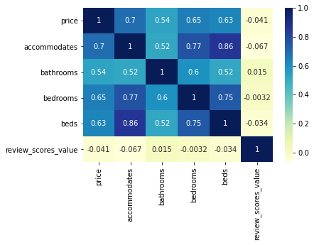

```python
# Correlation Heatmap
sns.heatmap(correl, xticklabels = correl.columns, annot=True, yticklabels = correl.columns, cmap="YlGnBu");
```

It looks like all features except 'review_scores_value' are relatively decent candidates, which is interesting because intuitively, you would think that the review score average for each listing would be somehow correlated with the price.

The 'accommodates' feature came out with the strongest relationship with 'price'. Let's see how that looks like in a scatter plot:

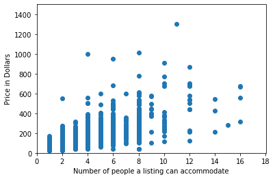

```python
plt.scatter(x = df['accommodates'], y = df['price'])
plt.xlim(0,18)
plt.ylim(0,1500)
plt.xlabel('Number of people a listing can accommodate')
plt.ylabel('Price in Dollars')
plt.show()
```

We see that there is a decent positive relationship there, which corresponds with the correlation coefficient of 0.7.

## Regression Analysis

We will be using a forward-feature-selection approach for the regression analysis. That is:

1. Model any feature first and then compare to other features
2. Combine the best features

#### Model any feature first and then compare to other features

We will start with the 'review_scores_value' feature because it was least correlated, so we will see if we can just eliminate it.

We look at two indicators in the regression summary to make a decision:

- Adjusted R-squared: The closer it is to 1, the better our input feature is at predicting our target variable
- P-value: Tests the significance of the relationship between each input feature and our target variable. A higher P-value (greater that 0.05 for a 95% confidence level) means less significance.

*Linear Model 1 - Feature is: 'review_scores_value'*

```python
df['intercept'] = 1
lm = sm.OLS(df['price'], df[['intercept','review_scores_value']])
result = lm.fit()
result.summary2()
```

| Model: | OLS | Adj. R-squared: | 0.001 |
| --- | --- | --- | --- |
| Dependent Variable: | price | AIC: | 36927.6392 |
| Date: | 2020-12-21 02:17 | BIC: | 36939.7007 |
| No. Observations: | 3074 | Log-Likelihood: | -18462. |
| Df Model: | 1 | F-statistic: | 5.113 |
| Df Residuals: | 3072 | Prob (F-statistic): | 0.0238 |
| R-squared: | 0.002 | Scale: | 9646.7 |

|  | Coef. | Std.Err. | t | P>\|t\| | [0.025 | 0.975] |
| --- | --- | --- | --- | --- | --- | --- |
| intercept | 186.0639 | 22.4340 | 8.2938 | 0.0000 | 142.0768 | 230.0510 |
| review_scores_value | -5.3483 | 2.3653 | -2.2612 | 0.0238 | -9.9859 | -0.7106 |

| Omnibus: | 2294.650 | Durbin-Watson: | 1.825 |
| --- | --- | --- | --- |
| Prob(Omnibus): | 0.000 | Jarque-Bera (JB): | 55245.319 |
| Skew: | 3.322 | Prob(JB): | 0.000 |
| Kurtosis: | 22.677 | Condition No.: | 121 |

Looking at the 'review_scores_value' feature, we already see that it will not be very helpful in our model for two reasons:

1. The Adjusted R-Squared is basically 0, Meaning there is no visible relationship.
2. The P-value for the intercept is less than the P-value for 'review_scores_value'. This is a big deal, because it suggests that the intercept model (basically just the mean price) is better at predicting the price than a model that includes 'review_scores_value'.

Hence, we will not be using this feature in our model.

*Linear Model 2 - Feature is: 'bathrooms'*

```python
df['intercept'] = 1
lm2 = sm.OLS(df['price'], df[['intercept','bathrooms']])
result2 = lm2.fit()
result2.summary2()
```

| Model: | OLS | Adj. R-squared: | 0.287 |
| --- | --- | --- | --- |
| Dependent Variable: | price | AIC: | 35892.0305 |
| Date: | 2020-12-21 02:17 | BIC: | 35904.0920 |
| No. Observations: | 3074 | Log-Likelihood: | -17944. |
| Df Model: | 1 | F-statistic: | 1238. |
| Df Residuals: | 3072 | Prob (F-statistic): | 3.86e-228 |
| R-squared: | 0.287 | Scale: | 6887.6 |

|  | Coef. | Std.Err. | t | P>\|t\| | [0.025 | 0.975] |
| --- | --- | --- | --- | --- | --- | --- |
| intercept | 23.7773 | 3.5106 | 6.7731 | 0.0000 | 16.8940 | 30.6605 |
| bathrooms | 88.9693 | 2.5288 | 35.1820 | 0.0000 | 84.0110 | 93.9277 |

| Omnibus: | 1492.139 | Durbin-Watson: | 1.840 |
| --- | --- | --- | --- |
| Prob(Omnibus): | 0.000 | Jarque-Bera (JB): | 43416.153 |
| Skew: | 1.712 | Prob(JB): | 0.000 |
| Kurtosis: | 21.090 | Condition No.: | 5 |

The 'bathrooms' feature is clearly helpful to our model given the two factors we stated earlier. But we're not done, let's add more features to the model!

*Linear Model 3 - Features are: 'bathrooms', 'beds'*

```python
df['intercept'] = 1
lm3 = sm.OLS(df['price'], df[['intercept','bathrooms', 'beds']])
result3 = lm3.fit()
result3.summary2()
```

| Model: | OLS | Adj. R-squared: | 0.456 |
| --- | --- | --- | --- |
| Dependent Variable: | price | AIC: | 35063.2886 |
| Date: | 2020-12-21 02:17 | BIC: | 35081.3808 |
| No. Observations: | 3074 | Log-Likelihood: | -17529. |
| Df Model: | 2 | F-statistic: | 1287. |
| Df Residuals: | 3071 | Prob (F-statistic): | 0.00 |
| R-squared: | 0.456 | Scale: | 5258.2 |

|  | Coef. | Std.Err. | t | P>\|t\| | [0.025 | 0.975] |
| --- | --- | --- | --- | --- | --- | --- |
| intercept | 4.7277 | 3.1288 | 1.5110 | 0.1309 | -1.4071 | 10.8625 |
| bathrooms | 47.3404 | 2.5886 | 18.2881 | 0.0000 | 42.2649 | 52.4160 |
| beds | 41.0727 | 1.3305 | 30.8690 | 0.0000 | 38.4638 | 43.6815 |

| Omnibus: | 1879.919 | Durbin-Watson: | 1.870 |
| --- | --- | --- | --- |
| Prob(Omnibus): | 0.000 | Jarque-Bera (JB): | 73635.855 |
| Skew: | 2.299 | Prob(JB): | 0.000 |
| Kurtosis: | 26.532 | Condition No.: | 7 |

As we can see, the 'beds' feature has significantly improved our model! Let's keep going and see how we can improve it further. This time, we will add two new features: 'bedrooms' and 'accommodates'.

```python
df['intercept'] = 1
lm4 = sm.OLS(df['price'], df[['intercept','bathrooms', 'beds', 'bedrooms','accommodates']])
result4 = lm4.fit()
result4.summary2()
```

| Model: | OLS | Adj. R-squared: | 0.538 |
| --- | --- | --- | --- |
| Dependent Variable: | price | AIC: | 34564.0435 |
| Date: | 2020-12-21 02:17 | BIC: | 34594.1972 |
| No. Observations: | 3074 | Log-Likelihood: | -17277. |
| Df Model: | 4 | F-statistic: | 894.0 |
| Df Residuals: | 3069 | Prob (F-statistic): | 0.00 |
| R-squared: | 0.538 | Scale: | 4467.1 |

|  | Coef. | Std.Err. | t | P>\|t\| | [0.025 | 0.975] |
| --- | --- | --- | --- | --- | --- | --- |
| intercept | -6.8832 | 2.9689 | -2.3184 | 0.0205 | -12.7045 | -1.0619 |
| bathrooms | 30.9943 | 2.5686 | 12.0667 | 0.0000 | 25.9580 | 36.0306 |
| beds | 0.1948 | 2.1469 | 0.0907 | 0.9277 | -4.0148 | 4.4043 |
| bedrooms | 21.7802 | 2.3961 | 9.0899 | 0.0000 | 17.0821 | 26.4784 |
| accommodates | 22.2817 | 1.2866 | 17.3181 | 0.0000 | 19.7590 | 24.8044 |

| Omnibus: | 2183.345 | Durbin-Watson: | 1.865 |
| --- | --- | --- | --- |
| Prob(Omnibus): | 0.000 | Jarque-Bera (JB): | 94495.670 |
| Skew: | 2.858 | Prob(JB): | 0.000 |
| Kurtosis: | 29.554 | Condition No.: | 15 |

It looks like the P-value for the 'beds' feature is too high. This means that, though this feature helped improve our model initially, it is actually dentrimental to our model when 'bedrooms' and 'accommodates' are added. Let's take the 'beds' feature out and see what happens.

```python
df['intercept'] = 1
lm5 = sm.OLS(df['price'], df[['intercept','bathrooms', 'bedrooms','accommodates']])
result5 = lm5.fit()
result5.summary2()
```

| Model: | OLS | Adj. R-squared: | 0.538 |
| --- | --- | --- | --- |
| Dependent Variable: | price | AIC: | 34562.0518 |
| Date: | 2020-12-21 02:17 | BIC: | 34586.1747 |
| No. Observations: | 3074 | Log-Likelihood: | -17277. |
| Df Model: | 3 | F-statistic: | 1192. |
| Df Residuals: | 3070 | Prob (F-statistic): | 0.00 |
| R-squared: | 0.538 | Scale: | 4465.7 |

|  | Coef. | Std.Err. | t | P>\|t\| | [0.025 | 0.975] |
| --- | --- | --- | --- | --- | --- | --- |
| intercept | -6.8950 | 2.9656 | -2.3249 | 0.0201 | -12.7098 | -1.0801 |
| bathrooms | 31.0127 | 2.5601 | 12.1138 | 0.0000 | 25.9930 | 36.0324 |
| bedrooms | 21.8295 | 2.3333 | 9.3557 | 0.0000 | 17.2546 | 26.4045 |
| accommodates | 22.3599 | 0.9552 | 23.4090 | 0.0000 | 20.4870 | 24.2327 |

| Omnibus: | 2183.290 | Durbin-Watson: | 1.865 |
| --- | --- | --- | --- |
| Prob(Omnibus): | 0.000 | Jarque-Bera (JB): | 94466.759 |
| Skew: | 2.858 | Prob(JB): | 0.000 |
| Kurtosis: | 29.550 | Condition No.: | 13 |

We see that the Adjusted R-squared value stayed the same but the F-statistic has increased. While the F-statistic is beyond the scope of this project, I should mention that when fine-tuning our regression model, in general we want this value to be as far away from 1 as possible. Hence, the increase here is good for our model.

As far as numeric features go, this is where we will stop for this model. But we're not done yet! Later on, we will inspect the feasibility of adding categorical variables to bolster our model.

#### VIFs and Multicollinearity

Here, we will check for the potential effects of multicollinearity in the model using Variance Inflation Factors (VIFs). As a convention, if a feature has a VIF that is greater than 10, existing multicollinearity could be harmful to the model, and hence that feature should potentially be removed from the model.

```python
y, X = dmatrices('price ~ bathrooms + bedrooms + accommodates', df, return_type = 'dataframe')
vif = pd.DataFrame()
vif["VIF Factor"] = [variance_inflation_factor(X.values, i) for i in range(X.shape[1])]
vif["features"] = X.columns
```

```python
vif
```

|  | VIF Factor | features |
| --- | --- | --- |
| 0 | 6.054204 | Intercept |
| 1 | 1.580747 | bathrooms |
| 2 | 2.804548 | bedrooms |
| 3 | 2.463001 | accommodates |

VIFs do not seem to be a problem for this model. Therefore, we can keep all the features we currently have!

#### Adding categorical input features to our model

```python
df[['Entire home/apt', 'Private room', 'Shared room']] =  pd.get_dummies(df['room_type'])
```

```python
df.head()
```

|  | id | price | neighbourhood_group_cleansed | property_type | room_type | accommodates | bathrooms | bedrooms | beds | review_scores_value | intercept | Entire home/apt | Private room | Shared room |
| --- | --- | --- | --- | --- | --- | --- | --- | --- | --- | --- | --- | --- | --- | --- |
| 0 | 4291 | 82.000000 | Other neighborhoods | House | Private room | 2 | 1.0 | 1 | 1 | 9.0 | 1 | 0 | 1 | 0 |
| 1 | 5682 | 53.944984 | Delridge | Apartment | Entire home/apt | 2 | 1.0 | 1 | 1 | 10.0 | 1 | 1 | 0 | 0 |
| 2 | 6606 | 92.849315 | Other neighborhoods | Apartment | Entire home/apt | 2 | 1.0 | 1 | 1 | 9.0 | 1 | 1 | 0 | 0 |
| 3 | 7369 | 85.000000 | Capitol Hill | Condominium | Entire home/apt | 2 | 1.0 | 1 | 1 | 9.0 | 1 | 1 | 0 | 0 |
| 4 | 9419 | 85.616438 | Other neighborhoods | House | Private room | 2 | 3.0 | 1 | 1 | 9.0 | 1 | 0 | 1 | 0 |

```python
df['intercept'] = 1
lm6 = sm.OLS(df['price'], df[['intercept','bathrooms', 'bedrooms','accommodates', 'Entire home/apt', 'Shared room']])
result6 = lm6.fit()
result6.summary2()
```

| Model: | OLS | Adj. R-squared: | 0.584 |
| --- | --- | --- | --- |
| Dependent Variable: | price | AIC: | 34237.1837 |
| Date: | 2020-12-21 02:17 | BIC: | 34273.3681 |
| No. Observations: | 3074 | Log-Likelihood: | -17113. |
| Df Model: | 5 | F-statistic: | 865.0 |
| Df Residuals: | 3068 | Prob (F-statistic): | 0.00 |
| R-squared: | 0.585 | Scale: | 4015.2 |

|  | Coef. | Std.Err. | t | P>\|t\| | [0.025 | 0.975] |
| --- | --- | --- | --- | --- | --- | --- |
| intercept | -25.0436 | 3.0780 | -8.1364 | 0.0000 | -31.0786 | -19.0085 |
| bathrooms | 37.5232 | 2.4533 | 15.2947 | 0.0000 | 32.7129 | 42.3336 |
| bedrooms | 28.3807 | 2.2403 | 12.6680 | 0.0000 | 23.9879 | 32.7734 |
| accommodates | 13.2734 | 1.0294 | 12.8941 | 0.0000 | 11.2550 | 15.2918 |
| Entire home/apt | 49.4147 | 2.8817 | 17.1477 | 0.0000 | 43.7644 | 55.0650 |
| Shared room | -28.3090 | 6.9836 | -4.0537 | 0.0001 | -42.0020 | -14.6161 |

| Omnibus: | 2427.347 | Durbin-Watson: | 1.847 |
| --- | --- | --- | --- |
| Prob(Omnibus): | 0.000 | Jarque-Bera (JB): | 137299.092 |
| Skew: | 3.279 | Prob(JB): | 0.000 |
| Kurtosis: | 35.077 | Condition No.: | 28 |

An Adjusted R-squared of 0.584 with a P-value of 0 for each coefficient brings us to our last model adjustment. While more can potentially be done to improve our prediction capabilities (say using another model), that is beyond the scope of this project. With these features though, we are able to explain 58.4% of the variation in Rental Prices through simple linear regression. While this is not perfect, it does at least explain the majority of the variation, and hence is a good predictive starting point.

## Conclusion

### Areas of Improvement

Evidently, a simple linear regression is not robust enough to predict rental prices accurately, but it is a good starting point. A noteworthy improvement would be incorporating a Sentiment Analysis using renter reviews, and then seeing how Sentiment Scores relate to prices. Another potential improvement would be using a Polynomial Regression to help predict prices. However, this approach would create a relatively higher risk of overfitting, and would need to be carefully regulated. The intention is to implement similar techniques and more in future projects and blogposts.